# Exponential Integrators

[AMath 586, Spring Quarter 2019](http://staff.washington.edu/rjl/classes/am586s2019/) at the University of Washington. For other notebooks, see Index.html or the [Index of all notebooks on Github](https://github.com/rjleveque/amath586s2019/blob/master/notebooks/Index.html).

This notebook gives a brief introduction to a class of ODE solvers called [exponential integrators](https://en.wikipedia.org/wiki/Exponential_integrator), focusing on the simples *Exponential Time Differencing (ETD)* methods described by:

- S.M. Cox and P.C. Matthews, *Exponential Time Differencing for Stiff Systems*, J. Comput. Phys. 176(2002), pp. 430-455. [[link]](https://pdfs.semanticscholar.org/9a47/a0c3f84a5aa1ef8016b8d9655951bc830933.pdf)

For more discussion, see e.g.

- M. Hochbruck and A. Ostermann, *Exponential integrators*, Acta Numerica 19 (2010), 209-286. [[link]](https://doi.org/10.1017/S0962492910000048)

```python
%matplotlib inline
```

```python
from pylab import *
from scipy.linalg import expm, solve
```

The basic idea is write the ODE $u'(t) = f(u(t))$, for example, as $u'(t) = Au(t) + g(u(t))$, where the matrix $A$ captures much of the stiffness of the problem and eigenvalues of the remaining Jacobian $g'(u)$ stay closer to the origin. Such a splitting naturally exists for some problems, or one might linearize in each time step.

Then we use the fact that over a single time step the true solution satisfies

$$ u(t_{n+1}) = \exp(Ak) u(t_n) + \int_{t_n}^{t_{n+1}} \exp(A(t_{n+1}-\tau) g(u(\tau)) \, d\tau. $$

If $g$ were a function of $t$ this would be Duhamel's principle. More generally it is sometimes called "variation of parameters" and no longer gives an explicit solution since $u(\tau)$ comes into the integral. But we can approximate the integral numerically using $U^n$ and either past values of $U^j$ or a multi-stage approach going forward, giving rise to many possible numerical methods.

The simplest arises from approximating $g(u(\tau)) \approx g(U^n)$ over the time interval, yielding

$$ U^{n+1} = \exp(Ak) U^n + (\exp(Ak) - I) A^{-1} g(U^n). $$

This is exact if $g(u)=0$ while as $A \rightarrow 0$ this approaches the forward Euler method on $u' = g(u)$.

## Absolute stability

We now replace the test problem with $u' = cu + \lambda u$ where $c$ corresponds to $A$ and is handled exactly while $\lambda$ represents an eigenvalue of $g(u)$. Applying the method gives

\begin{align*} U^{n+1} &= e^{ck}U^n + \frac 1 c \left(e^{ck}-1\right)\lambda U^n\\ &= \left( e^y + \frac 1 y \left(e^{y}-1\right) z\right) U^n \end{align*}

or $U^{n+1} = R(z,y) U^n$ where $y = ck$ and $z=\lambda k$. Since $c$ and $\lambda$ could both be complex, stability region is now in four dimensional space.

Below we show a typical stability region if we fix $y$ at some negative value and then consider what values of $z$ are allowed, natural in the study of stiff problems.

```python
def plotS(R, axisbox = [-10, 10, -10, 10], npts=500):
    """
    Compute |R(z)| over a fine grid on the region specified by axisbox
    and do a contour plot with contourf (filled contours)
    to show the region of absolute stability.
    """

    xa, xb, ya, yb = axisbox
    x = linspace(xa,xb,npts)
    y = linspace(ya,yb,npts)
    X,Y = meshgrid(x,y)
    Z = X + 1j*Y
    Rval = R(Z)
    Rabs = abs(Rval)

    # plot interior, exterior, as green and white:
    levels = [-1e9,1,1e9]
    CS1 = contourf(X, Y, Rabs, levels, colors = ('g', 'w'))

    # plot boundary as a black curve:
    CS2 = contour(X, Y, Rabs, [1,], colors = ('k',), linewidths = (2,))

    title('Region of absolute stability')
    grid(True)
    plot([xa,xb],[0,0],'k')  # x-axis
    plot([0,0],[ya,yb],'k')  # y-axis

    axis('scaled')  # scale x and y same so that circles are circular
    axis(axisbox)   # set limits
```

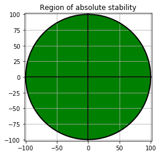

```python
ck = -100.
R = lambda z: exp(ck) + (exp(ck)-1)/ck * z
rr = -ck+2
plotS(R, axisbox = [-rr,rr, -rr,rr])
```

## Try it on a stiff reaction system

Consider the reactions

\begin{align*} &A \stackrel{K_{1}}{\rightarrow} B\\ &B+C \stackrel{K_{2}}{\rightarrow} D\\ &D \stackrel{K_{3}}{\rightarrow} A\\ \end{align*}

which gives the nonlinear system

\begin{align*} u_0'(t) &= -K_1u_0(t) + K_3 u_3(t)\\ u_1'(t) &= K_1u_0(t) - K_2 u_1(t)u_2(t)\\ u_2'(t) &= - K_2 u_1(t)u_2(t)\\ u_3'(t) &= K_2 u_1(t)u_2(t) - K_3 u_3(t)\\ \end{align*}

If $K_2$ is small relative to $K_1$ and/or $K_3$, then it may be possible to capture the stiff part with a linear system of equations.

```python
K1 = 100.
K2 = 0.5
K3 = 5.

def f(u):
    f0 = -K1*u[0] + K3*u[3]
    f1 = K1*u[0] - K2*u[1]*u[2]
    f2 = -K2*u[1]*u[2]
    f3 = K2*u[1]*u[2] - K3*u[3]
    return(array((f0,f1,f2,f3)))
```

### Forward Euler

First we apply Forward Euler to the full system to see when stability breaks down...

```python
t0 = 0.
tfinal = 2.
eta = array((1,2,3,4))

def euler(nsteps):
    t = linspace(t0, tfinal, nsteps+1)
    dt = t[1] - t[0]
    U = empty((4,nsteps+1))  # array for computed solution
    U[:,0] = eta
    for n in range(nsteps):
        U[:,n+1] = U[:,n] + dt * f(U[:,n])

    figure(figsize=(12,5))
    plot(t, U[0,:],'k', label='u0')
    plot(t, U[1,:],'b', label='u1')
    plot(t, U[2,:],'r', label='u2')
    plot(t, U[3,:],'c', label='u3')
    xlim(t0,tfinal)
    legend()  # uses the labels from the plot commands
    title('%i steps, dt = %7.4f' % (nsteps, dt))
```

With 300 timesteps we get a smooth solution:

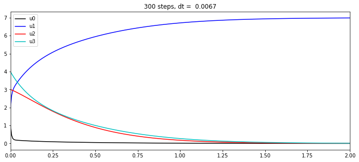

```python
euler(300)
```

Since $K_1 = 100$ is the largest rate we would expect the eigenvalues of the Jacobian to be on the order of $-100$ and so Forward Euler is only stable if $k\lambda > -2$ and we expect to need a time step around $k \approx 2/100$ for stability. To got up to time 2 we thus expect to need at least 100 time steps. Indeed this is at the limit of stability, with fewer steps the solution grows exponentially:

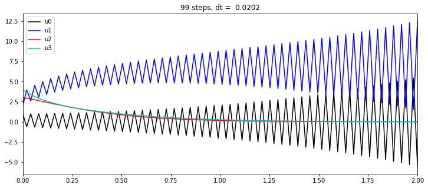

```python
euler(99)
```

Note the oscillation since $1 + k\lambda \approx -1$. Even with 150 time steps $1 + k\lambda < 0$ and there's an initial oscillation:

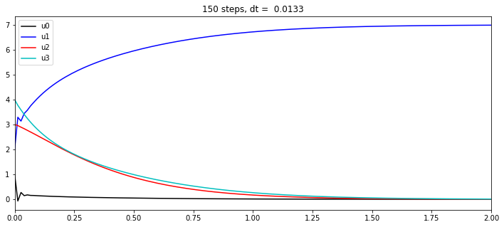

```python
euler(150)
```

### Test the exponential integrator

We define the $A$ matrix by pulling out the constant part of the Jacobian, and then adding the identity matrix to make it nonsingular, since we need to use $A^{-1}$ in this integrator. (Maybe there's a better splitting?)

We then define $g(u) = f(u) - Au$ to be what's left over, which is still a nonlinear function.

```python
A = array([[-K1,0,0,K3], [K1,0,0,0], [0,0,0,0], [0,0,0,-K3]]) + eye(4)

def g(u):
    return f(u) - A.dot(u)
```

Note that `A.dot(u)` or equivalently `dot(A,u)` gives the matrix-vector product. This is also used in the loop below.

We also use `expm` and `solve` from `scipy.linalg` for the matrix exponential and to solve a linear system: `solve(A,g)` gives $A^{-1}g$.

Also note that `expAk_I = expm(A*dt) - eye(4)` is computed before the time stepping loop, so the matrix exponential is only computed once. The updating formula has been rewritten as

$$ U^{n+1} = U^n + (\exp(Ak) - I) (U^n + A^{-1} g(U^n)). $$

so that there is only one linear system solve and one matrix-vector multiply each time through the loop.

```python
t0 = 0.
tfinal = 2.
eta = array((1,2,3,4))

def exp_euler(nsteps):
    t = linspace(t0, tfinal, nsteps+1)
    dt = t[1] - t[0]
    U = empty((4,nsteps+1))  # array for computed solution
    U[:,0] = eta

    expAk_I = expm(A*dt) - eye(4)
    for n in range(nsteps):
        Ainv_g = solve(A,g(U[:,n]))
        U[:,n+1] = U[:,n] + dot(expAk_I, U[:,n] + Ainv_g)

    figure(figsize=(12,5))
    plot(t, U[0,:],'k', label='u0')
    plot(t, U[1,:],'b', label='u1')
    plot(t, U[2,:],'r', label='u2')
    plot(t, U[3,:],'c', label='u3')
    xlim(t0,tfinal)
    legend()  # uses the labels from the plot commands
    title('%i steps, dt = %7.4f' % (nsteps, dt))
```

Now we get nicer results with 150 steps:

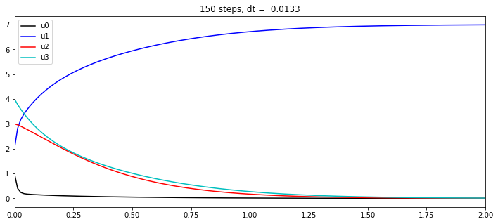

```python
exp_euler(150)
```

And the method stays stable even with only 10 steps (though not very accurate at this point):

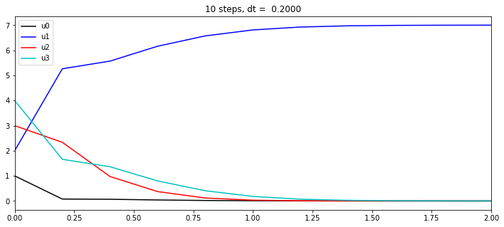

```python
exp_euler(10)
```